# Fantasy Football Draft Analysis: Resource Allocation Patterns

*i'm on the flight back from germany right now and the wifi sucks and i'm bored so i've decided to investigate our auction drafts.*

## Overall Spending Behavior

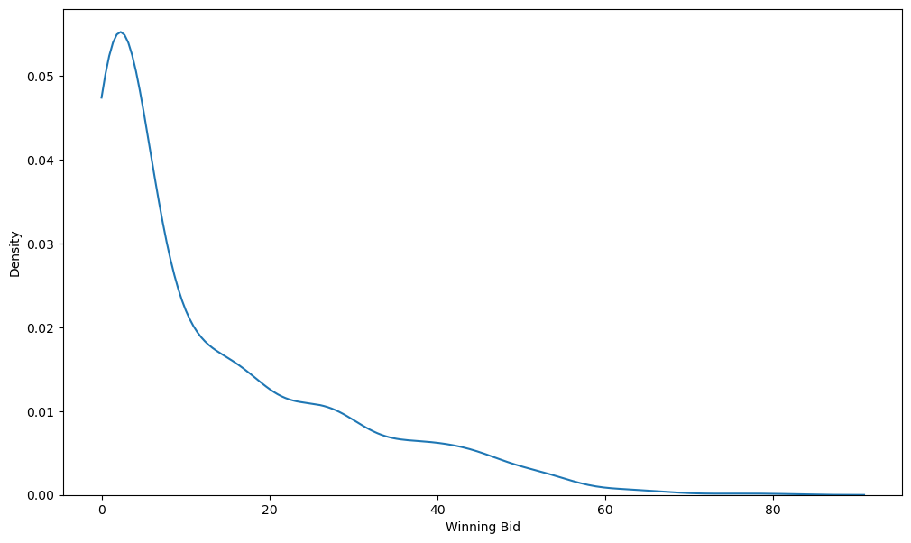

The max a player has spent on a player:

|  | NO. | Player | Team | Winning Bid | Year | Owner |
| --- | --- | --- | --- | --- | --- | --- |
| 0 | 1 | Christian McCaffrey Car, RB | DK CREW | 80 | 2020 | Derek |

We can also look at each owner and draft in this time range. First we'll look at 2025 before looking at only past seasons.

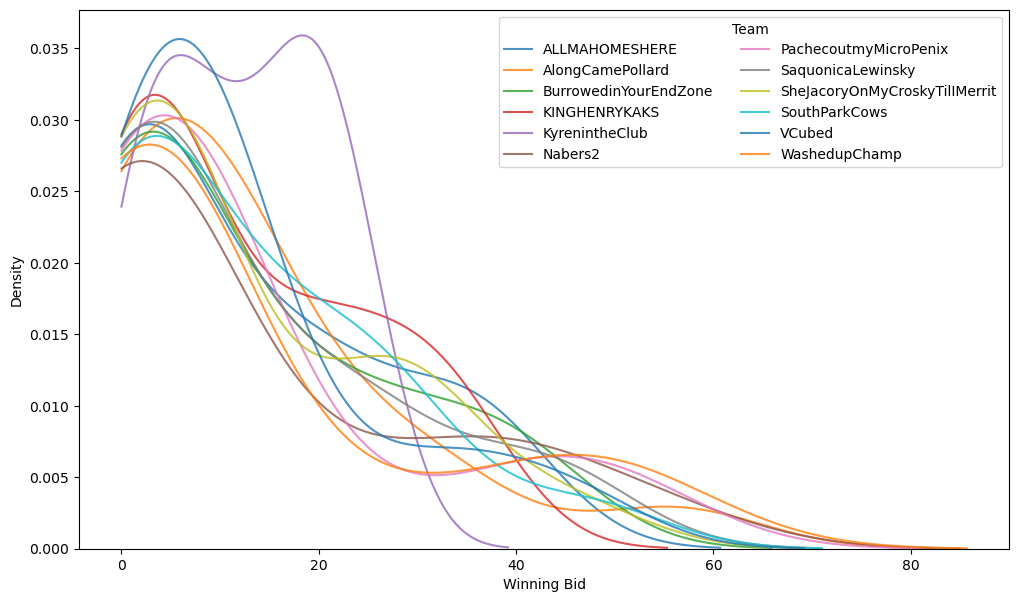

From now on I'll omit 2025. Sorry Luke and Jake.

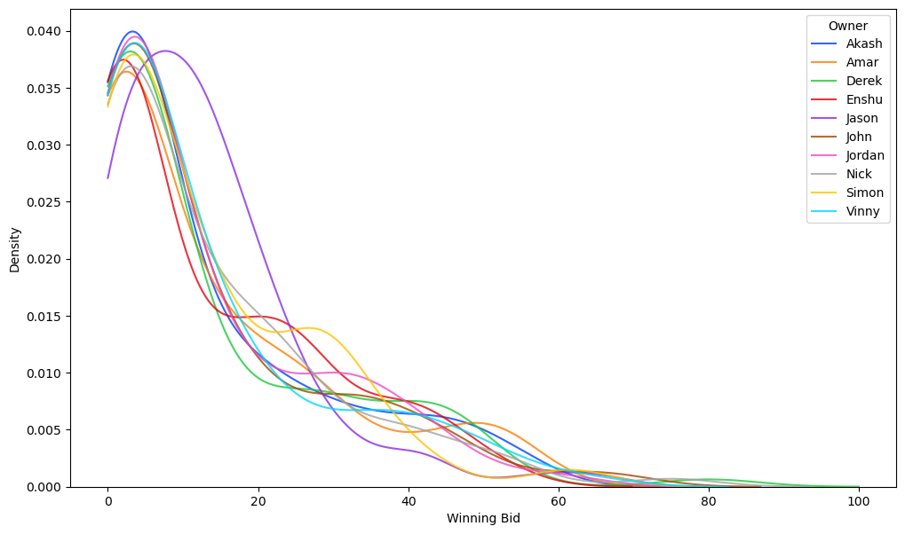

Why is Jason such an outlier? Let's look at the individual drafts

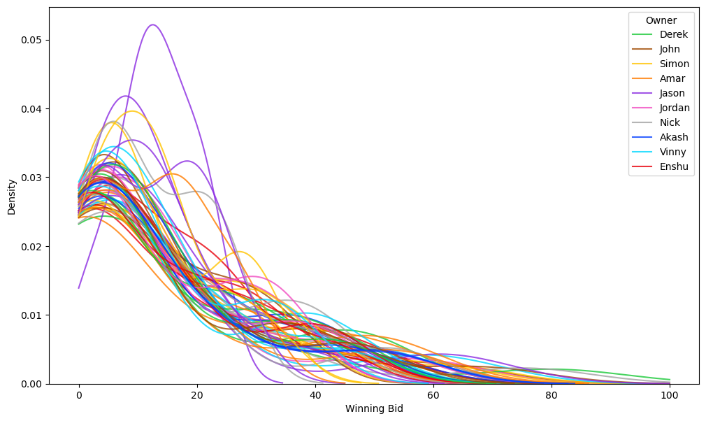

Let's look at that team of Jason's and how he did that year.

|  | NO. | Player | Team | Winning Bid | Year | Owner |
| --- | --- | --- | --- | --- | --- | --- |
| 0 | 26 | David Johnson Hou, RB | SPIKE Â | 21 | 2020 | Jason |
| 1 | 28 | Le'Veon Bell KC, RB | SPIKE Â | 22 | 2020 | Jason |
| 2 | 39 | Amari Cooper Dal, WR | SPIKE Â | 23 | 2020 | Jason |
| 3 | 45 | Melvin Gordon III Den, RB | SPIKE Â | 15 | 2020 | Jason |
| 4 | 46 | Russell Wilson Sea, QB | SPIKE Â | 12 | 2020 | Jason |
| 5 | 48 | Allen Robinson II Chi, WR | SPIKE Â | 18 | 2020 | Jason |
| 6 | 51 | Robert Woods LAR, WR | SPIKE Â | 18 | 2020 | Jason |
| 7 | 54 | Raheem Mostert SF, RB | SPIKE Â | 11 | 2020 | Jason |
| 8 | 55 | A.J. Green Cin, WR | SPIKE Â | 7 | 2020 | Jason |
| 9 | 57 | T.Y. Hilton Ind, WR | SPIKE Â | 11 | 2020 | Jason |
| 10 | 59 | Zach Ertz Phi, TE | SPIKE Â | 14 | 2020 | Jason |
| 11 | 67 | Jarvis Landry Cle, WR | SPIKE Â | 9 | 2020 | Jason |
| 12 | 78 | Mark Ingram II FA, RB | SPIKE Â | 12 | 2020 | Jason |
| 13 | 79 | Julian Edelman NE, WR | SPIKE Â | 3 | 2020 | Jason |
| 14 | 97 | Colts D/ST Ind, D/ST | SPIKE Â | 1 | 2020 | Jason |

|  | RK | Team | REC | PF | PA | PF/G | PA/G | DIFF | Year | Owner |
| --- | --- | --- | --- | --- | --- | --- | --- | --- | --- | --- |
| 8 | 9 | SPIKE Â (Jason Schneiderman) | 5-8-0 | 1338.92 | 1565.9 | 103.0 | 120.5 | -17.5 | 2020 | Jason |

## Measuring Draft Strategy with Gini Coefficient

We can use Gini coefficient, which is used to quantify economic inequality, as a way of quantifying draft approaches. A higher Gini means more "stars and scrubs" strategy, while a lower Gini means more balanced spending.

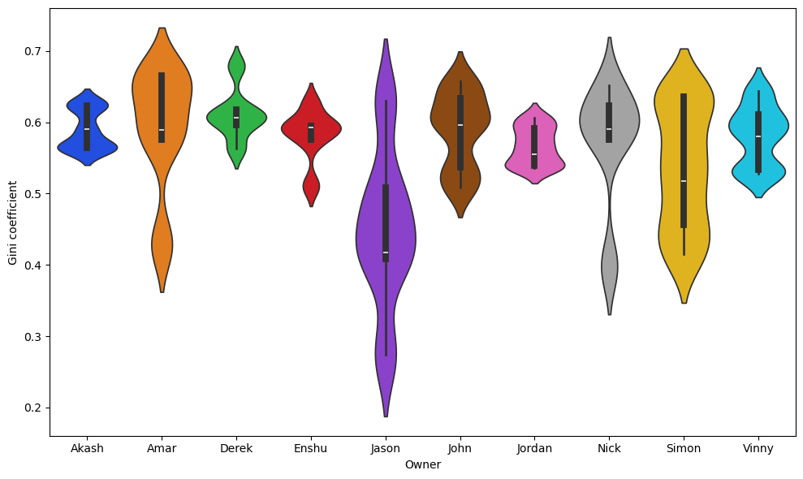

Or, if we average by Owner.

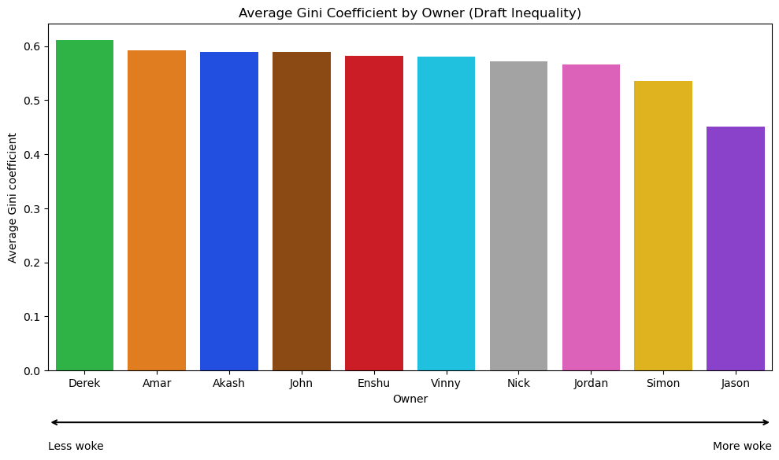

Jason's team from above is the least unequal team. Meanwhile, Derek's team with the $80 CMC is the most.

|  | NO. | Player | Team | Winning Bid | Year | Owner |
| --- | --- | --- | --- | --- | --- | --- |
| 0 | 1 | Christian McCaffrey Car, RB | DK CREW | 80 | 2020 | Derek |
| 1 | 20 | Joe Mixon Cin, RB | DK CREW | 41 | 2020 | Derek |
| 2 | 33 | James Conner Pit, RB | DK CREW | 28 | 2020 | Derek |
| 3 | 62 | Sterling Shepard NYG, WR | DK CREW | 2 | 2020 | Derek |
| 4 | 71 | DK Metcalf Sea, WR | DK CREW | 12 | 2020 | Derek |
| 5 | 85 | Dak Prescott Dal, QB | DK CREW | 5 | 2020 | Derek |
| 6 | 91 | Michael Gallup Dal, WR | DK CREW | 14 | 2020 | Derek |
| 7 | 93 | Jalen Reagor Phi, WR | DK CREW | 2 | 2020 | Derek |
| 8 | 108 | Eagles D/ST Phi, D/ST | DK CREW | 1 | 2020 | Derek |
| 9 | 111 | John Brown Buf, WR | DK CREW | 2 | 2020 | Derek |
| 10 | 112 | Hayden Hurst Atl, TE | DK CREW | 4 | 2020 | Derek |
| 11 | 115 | Jamison Crowder NYJ, WR | DK CREW | 3 | 2020 | Derek |
| 12 | 117 | Antonio Gibson Wsh, RB | DK CREW | 3 | 2020 | Derek |
| 13 | 126 | Hunter Henry LAC, TE | DK CREW | 1 | 2020 | Derek |
| 14 | 132 | Tony Pollard Dal, RB | DK CREW | 1 | 2020 | Derek |

## Linking Draft Strategy to Performance

Now let's see if there's a correlation between how managers spend their money and how well their teams perform? Meh not really.

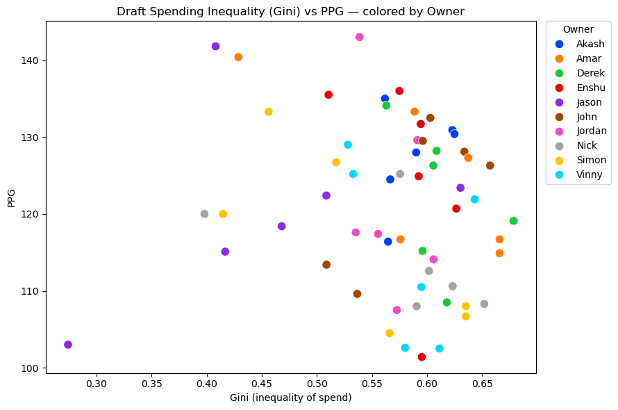

## Positional Analysis

Let's examine how managers allocate their budget across different positions

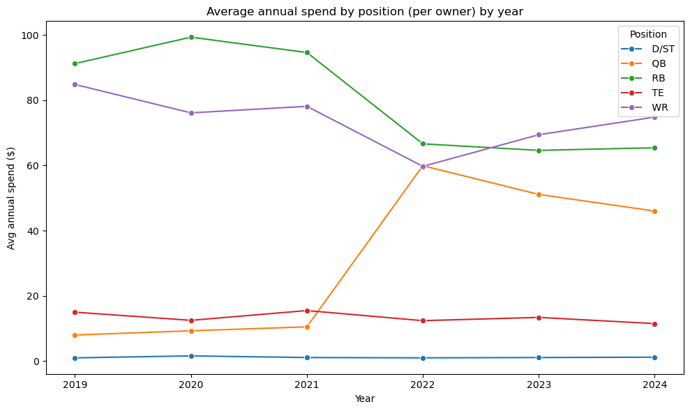

### Spending by Position and Owner

How much does each owner typically spend on each position?

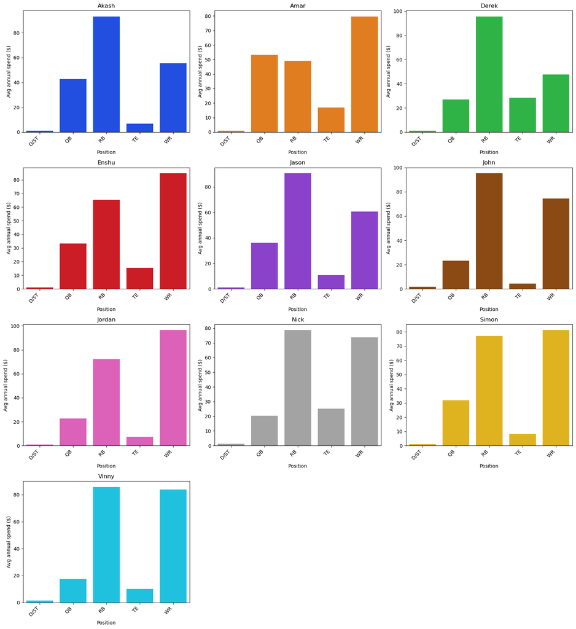

### Spending by Position Across All Owners

Now let's see how all owners compare on each position

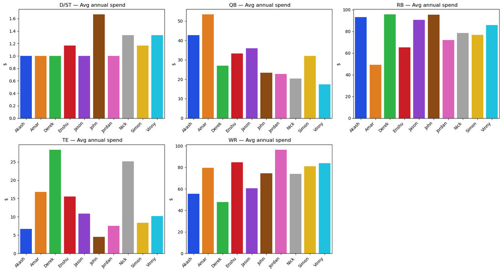

### Position Spending vs Performance

Does spending more on certain positions actually lead to better team performance?

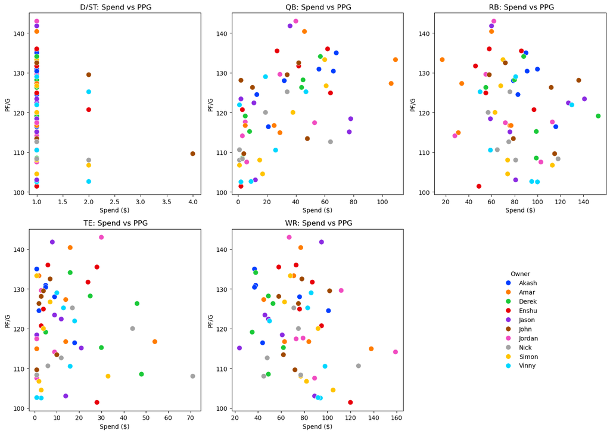

Ok that's all sorry I don't have any conclusions.